# Analyzing Spotify Top Songs 2000-2019 to help increase youtube views for aspiring instrumental cover youtubers Using R

12/12/2023

# Project Inspiration

I have been learning the guitar for a decade and it has always been a passion of mine to share my own guitar cover videos of songs/pieces that I like. I was always in awe to discover the talents on youtube and even found it quite astonishing that some youtubers could gain a lot of views from youtube videos by just playing instruments. This showed people really appreciated true talet. Therefore, I am working on this project to try to analyze what upcoming music will be popular to help musicians to pick songs to cover to increase their popularity. To make data-driven recommendations, I set and address some questions using data analysis process: ask, prepare, process, analyze, share and act.

# *ASK*

### Scenario

By learning from past data of listener’s preference on Spotify, my task is to analyze data on Spotify and extracting insights from popular music to inform youtubers about decisions on instrumental covers. I have come up with the following questions for my analysis:

1. What are the general characteristics of popular song hits ?
2. Which song key (major/minor) tend to lead to higher popularity ?
3. What key do popular songs tend to be in ?

# *PREPARE*

The dataset about top hits from 2000-2019 is pulled from Kaggle. The details are as follows:

**Name:** Top Hits Spotify from 2000-2019  
**Credit:** MARK KOVERHA  
**Source:** Spotify  
**Link:** https://www.kaggle.com/datasets/paradisejoy/top-hits-spotify-from-20002019/data  
**Format:** CSV file, 18 columns, 2000 rows  
**Metadata:**

- artist, song, duration_ms, explicit, year tells us some basic information of the song.
- popularity: higher value refers to higher popularity
- genre: genre of the song
- danceability, energy, key, loudness,mode, speechiness, acousticness, instrumentalness, liveness, valence, tempo: music characterics of the song

# *PROCESS*

```r
# load_packages
library(tidyverse)
```

```r
library(dplyr)
library(ggplot2)
```

```r
spotify_songs <- read.csv("songs_normalize.csv")
tibble(spotify_songs)
```

```
## # A tibble: 2,000 × 18
##    artist  song  duration_ms explicit  year popularity danceability energy   key
##    <chr>   <chr>       <int> <chr>    <int>      <int>        <dbl>  <dbl> <int>
##  1 Britne… Oops…      211160 False     2000         77        0.751  0.834     1
##  2 blink-… All …      167066 False     1999         79        0.434  0.897     0
##  3 Faith … Brea…      250546 False     1999         66        0.529  0.496     7
##  4 Bon Jo… It's…      224493 False     2000         78        0.551  0.913     0
##  5 *NSYNC  Bye …      200560 False     2000         65        0.614  0.928     8
##  6 Sisqo   Thon…      253733 True      1999         69        0.706  0.888     2
##  7 Eminem  The …      284200 True      2000         86        0.949  0.661     5
##  8 Robbie… Rock…      258560 False     2000         68        0.708  0.772     7
##  9 Destin… Say …      271333 False     1999         75        0.713  0.678     5
## 10 Modjo   Lady…      307153 False     2001         77        0.72   0.808     6
## # ℹ 1,990 more rows
## # ℹ 9 more variables: loudness <dbl>, mode <int>, speechiness <dbl>,
## #   acousticness <dbl>, instrumentalness <dbl>, liveness <dbl>, valence <dbl>,
## #   tempo <dbl>, genre <chr>
```

```r
#check if there is any duplicated data
spotify_songs_unique <- spotify_songs %>% distinct()
x <- nrow(spotify_songs) - nrow(spotify_songs_unique)
paste(x, "rows of data were duplicated and were removed from the dataset")
```

```
## [1] "59 rows of data were duplicated and were removed from the dataset"
```

```r
#check if there is any rows with missing information
spotify_songs_clean <- spotify_songs_unique[!apply(is.na(spotify_songs_unique) | spotify_songs_unique == "", 1, all),]
empty <- nrow(spotify_songs_unique) - nrow(spotify_songs_clean)
paste(empty, "rows of data were empty or stated not applicable and were removed from the dataset")
```

```
## [1] "0 rows of data were empty or stated not applicable and were removed from the dataset"
```

```r
write.csv(spotify_songs_clean, file='spotify_cleaned.csv')
```

# Analyze

First of all, the mean, min value, max value and standard deviation were found for the attributes to learn about the general characterics of the top hits in this dataset. The general characterictics can give a hint of the metrics of an average popular song.

```r
data <- read.csv("spotify_cleaned.csv")
#popularity
popularity_min <- min(data$popularity)
popularity_max <- max(data$popularity)
popularity_mean <- mean(data$popularity)
popularity_sd <- sd(data$popularity)
#danceability
danceability_min <- min(data$danceability)
danceability_max <- max(data$danceability)
danceability_mean <- mean(data$danceability)
danceability_sd <- sd(data$danceability)
#energy
energy_min <- min(data$energy)
energy_max <- max(data$energy)
energy_mean <- mean(data$energy)
energy_sd <- sd(data$energy)
#key
key_min <- min(data$key)
key_max <- max(data$key)
key_mean <- mean(data$key)
key_sd <- sd(data$key)
#loudness
loudness_min <- min(data$loudness)
loudness_max <- max(data$loudness)
loudness_mean <- mean(data$loudness)
loudness_sd <- sd(data$loudness)
#mode
mode_min <- min(data$mode)
mode_max <- max(data$mode)
mode_mean <- mean(data$mode)
mode_sd <- sd(data$mode)
#speechiness
speechiness_min <- min(data$speechiness)
speechiness_max <- max(data$speechiness)
speechiness_mean <- mean(data$speechiness)
speechiness_sd <- sd(data$speechiness)
#acoustiness
acousticness_min <- min(data$acousticness)
acousticness_max <- max(data$acousticness)
acousticness_mean <- mean(data$acousticness)
acousticness_sd <- sd(data$acousticness)
#instrumentalness
instrumentalness_min <- min(data$instrumentalness)
instrumentalness_max <- max(data$instrumentalness)
instrumentalness_mean <- mean(data$instrumentalness)
instrumentalness_sd <- sd(data$instrumentalness)
#liveness
liveness_min <- min(data$liveness)
liveness_max <- max(data$liveness)
liveness_mean <- mean(data$liveness)
liveness_sd <- sd(data$liveness)
#valence
valence_min <- min(data$valence)
valence_max <- max(data$valence)
valence_mean <- mean(data$valence)
valence_sd <- sd(data$valence)
#tempo
tempo_min <- min(data$tempo)
tempo_max <- max(data$tempo)
tempo_mean <- mean(data$tempo)
tempo_sd <- sd(data$tempo)
#export table
summary_table <-data.frame(
    MIN=c(popularity_min, danceability_min, energy_min,key_min, loudness_min,mode_min,speechiness_min,acousticness_min,instrumentalness_min,liveness_min,valence_min, tempo_min),
    MAX=c(popularity_max,danceability_max,energy_max,key_max,loudness_max,mode_max,speechiness_max,acousticness_max,instrumentalness_max, liveness_max, valence_max, tempo_max ),
    MEAN=c(popularity_mean,danceability_mean,energy_mean,key_mean,loudness_mean, mode_mean,speechiness_mean, acousticness_mean, instrumentalness_mean,liveness_mean, valence_mean,tempo_mean),
    SD=c(popularity_sd,danceability_sd,energy_sd,key_sd, loudness_sd,mode_sd,speechiness_sd,acousticness_sd,instrumentalness_sd, liveness_sd,valence_sd,tempo_sd))
    rownames(summary_table)<-c("popularity","danceability","energy", "key", "loundess","mode","speechiness","acousticness","instrumentalness","liveness","valence","tempo")
print(summary_table)
```

```
##                          MIN     MAX         MEAN          SD
## popularity         0.0000000  89.000  59.63317877 21.50105276
## danceability       0.1290000   0.975   0.66781401  0.14060828
## energy             0.0549000   0.999   0.72154869  0.15287162
## key                0.0000000  11.000   5.36939722  3.61526989
## loundess         -20.5140000  -0.276  -5.51408243  1.93895046
## mode               0.0000000   1.000   0.55332303  0.49727664
## speechiness        0.0232000   0.576   0.10378259  0.09614784
## acousticness       0.0000192   0.976   0.12817265  0.17258382
## instrumentalness   0.0000000   0.985   0.01537248  0.08837137
## liveness           0.0215000   0.853   0.18172633  0.14090954
## valence            0.0381000   0.973   0.55296615  0.22084538
## tempo             60.0190000 210.851 120.15844204 26.99047454
```

```r
write.csv(summary_table,file="summary_table.csv")
```

```r
music_characteristics_analysis <- read.csv("spotify_cleaned.csv")
high_popularity <- music_characteristics_analysis %>%  filter(popularity>=75)
total_no_of_songs <- nrow(high_popularity)
paste("Number of songs with high popularity: ",total_no_of_songs)
```

```
## [1] "Number of songs with high popularity:  397"
```

# Major/ Minor key

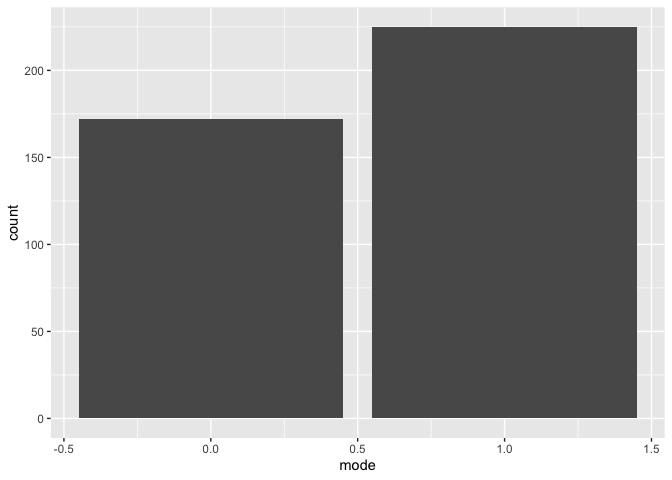

```r
ggplot(data=high_popularity)+
    geom_bar(mapping=aes(x=mode))
```

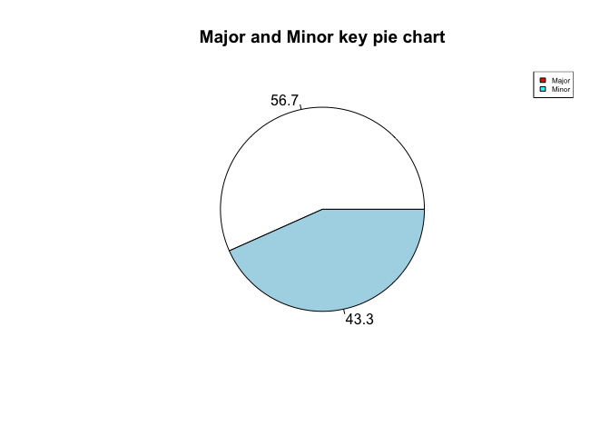

```r
major_songs <- music_characteristics_analysis %>%  filter(popularity>=75 & mode ==1)
minor_songs <- music_characteristics_analysis %>%  filter(popularity>=75 & mode == 0)
no_of_major_songs <- nrow(major_songs)
no_of_minor_songs <- nrow(minor_songs)
pie_chart_data <-c(no_of_major_songs, no_of_minor_songs)
pie_chart_labels<-c("Major","Minor")
piepercent <- round(100* pie_chart_data/sum(pie_chart_data),1)
pie(pie_chart_data,labels = piepercent, main="Major and Minor key pie chart")
legend("topright",c("Major","Minor"), cex=0.5,fill=rainbow(length(pie_chart_data)))
```

# Key

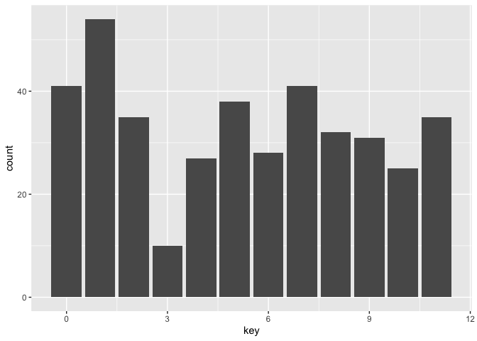

```r
ggplot(data=high_popularity)+
    geom_bar(mapping=aes(x=key))
```

# *SHARE*

# *ACT*